**Colab Guideline**

Instructor: Prof. Seungchul Lee  
http://iai.postech.ac.kr/  
Industrial AI Lab at POSTECH

Table of Contents

# 1. Overview

- 내용
  - 본 메뉴얼은 Colab 및 구글 드라이브 사용법을 다룸
- Colab
  - Ram,하드디스크,속도 등 Colab pro가 아닌 Colab을 기준으로 함
- Browser
  - 편의를 위해 Browser는 Chrome으로 통일

# 2. Requirment

- Computer spec
  - 데스크탑, 컴퓨터, 휴대폰 상관없이 동작 가능.
- Python, Anaconda 설치 유무
  - Python과 Anaconda가 설치되어 있지 않아도 상관없음
- Only needed
  - 구글 계정, 구글 드라이브. Chrome browser, Wifi

# 3. 구글 드라이브에서 코랩 설치 및 사용

## 3.1. 코랩 설치 방법

- Chrome에서 구글 계정 로그인
- https://www.google.com/intl/ko_KR/drive/ 로 이동하여 우측 상단에 [드라이브로 이동]을 클릭
- 왼쪽 상단에 [새로 만들기]-[더보기]-[연결한 앱 더보기]에서 돋보기 모양을 클릭하여 아래와 같이 Colaboratory를 검색하여 설치

[figure not shown]

## 3.2. 코랩 노트북 셀 편집

1. 설치가 완료되면, [드라이브]-[새로 만들기]-[더보기]에서 [Google Colaboratory]를 선택하면 Colab Notebook이 실행됨
2. [삽입]-[코드 셀(ctrl+B)]로 셀을 추가 가능
3. [런타임]-[선택항목 실행(ctrl+enter)] 혹은 셀 옆에 화살표를 클릭하여 해당 셀을 실행 가능
4. 셀을 실행할 때마다, 셀 옆에 실행 순서가 번호에 출력되는데, 중앙 상단에 [런타임]-[다시시작 및 모두 실행]을 클릭하면 차례로 모든 셀이 다시 실행됨
5. 왼쪽 상단에 텍스트를 클릭하면, 텍스트 셀이 생성됨
6. 왼쪽 상단에 "Untitled.ipynb"의 파일의 이름을 "iai postech"으로 변경하고, [ctrl]+[s]나 [파일]-[저장]을 하면 구글 드라이브에 저장된 것을 확인 가능

[figure not shown]

## 3.3. GPU 사용 설정

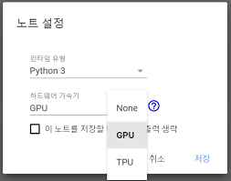

- "!nvidia-smi"을 셀에 입력해서 실행시키면, GPU와 CUDA 버전을 확인 가능

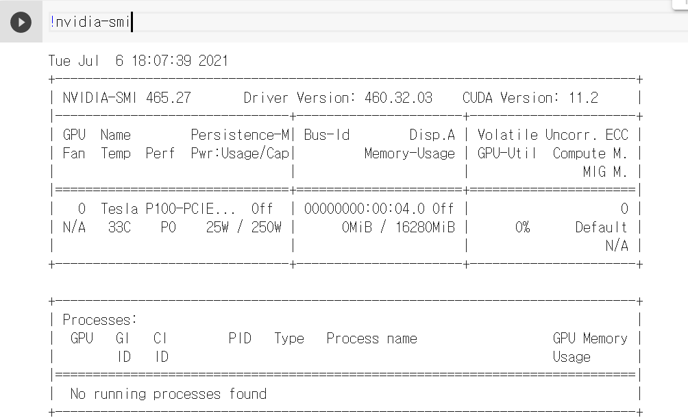

## 3.4. 로컬 파일을 코랩으로 불러오는 방법

코랩은 Jupyter Notebook이나 Pycharm과는 다른 가상 환경을 이용하기 때문에, 로컬 파일을 코랩으로 불러오는 과정이 필요. 파일을 구글 코랩에 불러오는 방법과 구글 드라이브를 코랩으로 불러오는 방법 2가지가 존재

### 3.4.1. 파일을 구글 코랩에 불러오는 방법

1) "from google.colab import files"를 셀에 입력하고 실행

[figure not shown]

.

2) "uploaded=files.upload()"를 입력하여 실행시켜주면, 셀 아래에 파일 선택이라는 버튼이 나옴. 버튼을 클릭하여, 로컬 파일을 업로드 가능

[figure not shown]

3) 업로드가 완료가 되면 아래 그림과 같이 왼쪽 바에 폴더 모양을 클릭해주면, 로컬 파일이 올라와 있는 것을 확인 가능

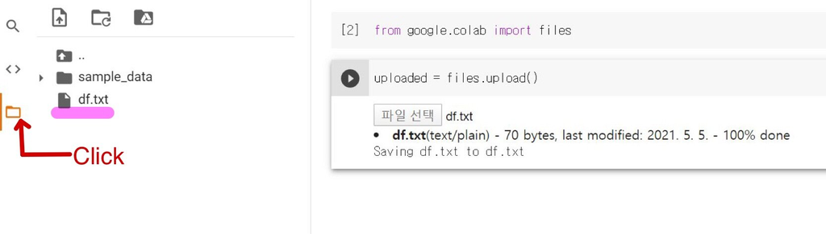

### 3.4.2. 구글 드라이브를 통해 불러오는 방법

1) 왼쪽 바에 밑에서 세번 째 폴더를 클릭하면, 파일 아이콘, 폴도 아이콘 그리고 드라이브 아이콘 3가지가 뜸. 그 중 맨 오른쪽의 드라이브 아이콘을 클릭

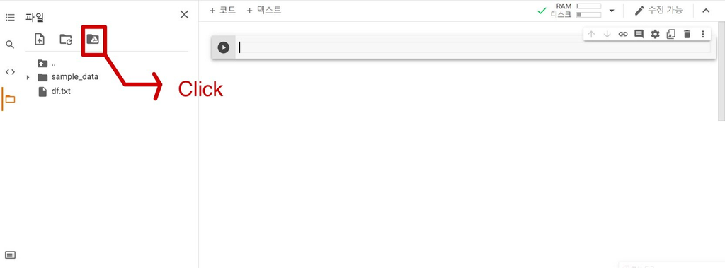

2) "노트북이 Google Drive 파일에 엑세스하도록 허용하시겠습니까?"라는 창이 나오면, [Google Drive에 연결]을 클릭

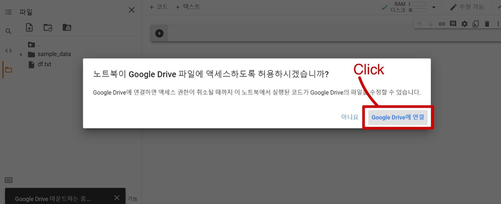

3) 그림과 같이, drive가 Colab에 업로드 된 것을 확인 가능

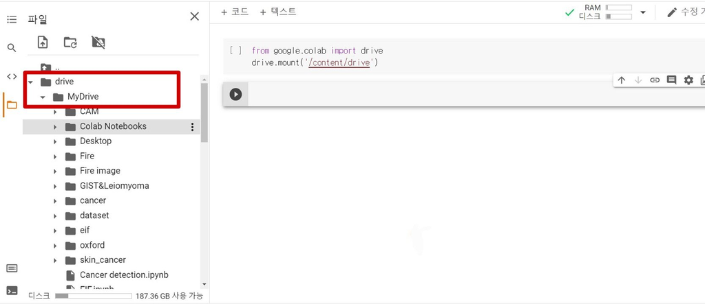

**만약 구글 드라이브가 업로드 되지 않으면**

1) 셀에 다음과 같은 코드를 입력

```
from google.colab import drive
drive.mount('/content/drive')
```

2) 실행을 하면, 아래 그림과 같이 Url 주소가 나옴

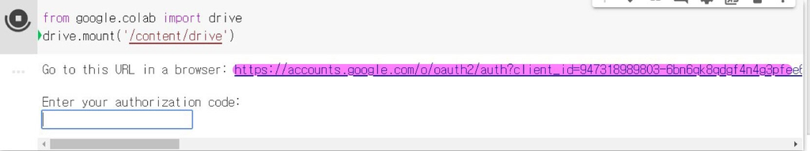

3) Url 주소를 클릭하면, 아래 그림과 같은 창을 볼 수 있는데, 네모난 아이콘을 클릭

[figure not shown]

4) 다시 Colab으로 돌아가, "Enter your authorization code:" 밑의 빈칸에 [Ctrl]+[v]를 누르고, [Enter]를 누르면, 정상적으로 드라이브가 Colab에 업로드 됨

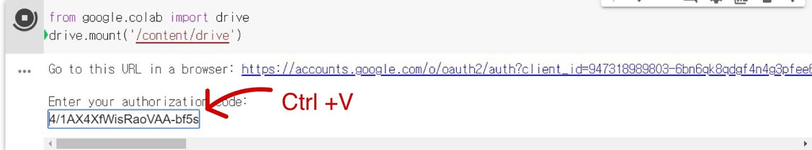

## 3.5. 런타임 관련해서 유의사항

> 문제 : Colab을 이용하다보면, "런타임 연결 초과"와 같은 문구를 많이 볼 수 있다. 실제 Colab의 런타임은 12시간이지만, 90분 동안 컴퓨터에 아무런 동작이 없으면, 런타임이 끊어지게 됨

[figure not shown]

.

> 해결 : Colab 창에서, [F12] 키보드를 누르게 되면, Console 창이 나오는데, 다음의 코드를 입력함으로써, 짧은 시간에 런타임이 끊어지는 것을 방지할 수 있음

```
function ClickConnect() {var buttons = document.querySelectorAll("colab-dialog.yes-no-dialog paper-button#cancel"); buttons.forEach(function(btn) { btn.click(); }); console.log("1분마다 자동 재연결"); document.querySelector("colab-toolbar-button#connect").click(); } setInterval(ClickConnect,1000*60);
```

[figure not shown]

.

```python
%%javascript
$.getScript('https://kmahelona.github.io/ipython_notebook_goodies/ipython_notebook_toc.js')
```